# TRABAJO DATA SCIENCE

ANÁLISIS ESTADÍSTICO PARA LA PREDICCIÓN DE ENFERMEDADES CARDIOVASCULARES

Lucía Dávalos, María Cañal

## INTRODUCCIÓN

Las enfermedades cardiovasculares representan una de las principales causas de mortalidad a nivel mundial. Según la Organización Mundial de la Salud (OMS), más de 12 millones de personas fallecen cada año a causa de patologías del corazón. Comprender los factores de riesgo asociados a este tipo de enfermedades es fundamental para mejorar la prevención y la salud pública.

El objetivo de este proyecto es realizar un análisis estadístico y exploratorio de distintos factores relacionados con la salud cardiovascular. Se pretende observar cómo una serie de variables pueden estar asociadas al riesgo de desarrollar una enfermedad coronaria a diez años. Para ello, se buscará identificar patrones relevantes, correlaciones significativas y posibles diferencias entre grupos de la población.

## OBTENCIÓN Y EXPLICACIÓN DEL SET DE DATOS

El conjunto de datos utilizado procede de la plataforma **Kaggle** y está basado en el reconocido **Framingham Heart Study**, un estudio realizado en la ciudad de Framingham, Massachusetts (EE. UU.).

El dataset incluye información de **3.390 individuos**, con variables que abarcan aspectos **demográficos, de comportamiento y médicos**, tales como edad, sexo, nivel de colesterol, presión arterial, hábito tabáquico, diabetes, índice de masa corporal o frecuencia cardíaca, entre otros. La variable `TenYearCHD` indica si un individuo presenta o no riesgo de sufrir una enfermedad coronaria en los próximos diez años.

## METODOLOGÍA

Se buscará obtener estadísticas descriptivas y combinadas que permitan identificar patrones y relaciones entre las variables. Se comenzará con la **importación de los datos** y su **preparación**, realizando limpieza de valores faltantes, corrección de posibles errores y normalización de las variables cuando sea necesario.

A continuación, se realizará una **exploración estadística y visual** para comprender la distribución de las variables, su dispersión y posibles asociaciones. Esto vendrá acompañado de una gran variedad de gráficos para entender mejor el comportamiento de los datos.

Se aplicarán también **técnicas de contraste de hipótesis** y pruebas estadísticas para identificar diferencias significativas entre grupos, por ejemplo, comparando hombres y mujeres, fumadores y no fumadores, o distintos rangos de edad. Además, se llevará a cabo un **Análisis de Componentes Principales (PCA)** para estudiar patrones globales y posibles agrupamientos dentro del conjunto de datos.

El trabajo se organizará en las siguientes secciones:

**Análisis exploratorio y estadístico de datos**:

1. Importar librerías y datos: Carga del dataset y librerías necesarias para el análisis en R.
2. Limpieza y preparación de datos: Procesamiento de valores faltantes, eliminación de duplicados y normalización de variables.
3. Visualización descriptiva de variables: Exploración gráfica de las variables principales mediante histogramas, gráficos de dispersión y boxplots.

**Ejercicios de análisis estadístico**:

Ejercicio 1: Test de Fisher – Contraste de independencia entre variables categóricas.

Ejercicio 2: Análisis del colesterol según edad y riesgo de CHD – Evaluación de la relación entre el nivel de colesterol, la edad y el riesgo cardiovascular.

Ejercicio 3: Análisis de correlaciones y PCA – Estudio de la relación entre variables cuantitativas y reducción de la dimensionalidad para identificar patrones globales.

**Resultados y conclusiones**: síntesis de los hallazgos obtenidos, interpretación de los resultados estadísticos y discusión sobre su relevancia en el contexto de la salud cardiovascular.

El propósito de esta metodología es obtener una comprensión completa de los factores de riesgo cardiovascular, explorando cómo se relacionan las distintas variables entre sí y detectando patrones que puedan ser relevantes para la investigación epidemiológica y la salud pública.

## ANÁLISIS EXPLORATORIO Y ESTADÍSTICO DE DATOS

El conjunto de datos contiene información de 3.390 personas y un total de 15 variables. Cada una de ellas representa un posible factor de riesgo cardiovascular. A continuación, se describen brevemente las principales variables incluidas:

**sex:** variable binaria que indica el sexo del individuo (1 = hombre, 0 = mujer).  
**age:** edad del participante en años.  
**education:** nivel educativo alcanzado.  
**currentSmoker:** indica si el individuo fuma actualmente (1 = sí, 0 = no).  
**cigsPerDay:** número medio de cigarrillos fumados por día.  
**BPMeds:** indica si la persona toma medicación para la presión arterial.  
**prevalentStroke:** indica si el participante ha sufrido un ictus previo.  
**prevalentHyp:** indica si el participante presenta hipertensión diagnosticada.  
**diabetes:** indica si el participante padece diabetes.  
**totChol:** nivel total de colesterol en mg/dL.  
**sysBP:** presión arterial sistólica.  
**diaBP:** presión arterial diastólica.  
**BMI:** índice de masa corporal.  
**heartRate:** frecuencia cardíaca en reposo.  
**glucose:** nivel de glucosa en sangre.  
**TenYearCHD:** variable objetivo que indica si el participante desarrollará o no enfermedad coronaria en los próximos 10 años (1 = sí, 0 = no).

Este conjunto de variables permitirá realizar un análisis completo de los factores que pueden influir en la salud cardiovascular, combinando información médica y hábitos de vida. El estudio se centrará en examinar las relaciones entre estas variables y en detectar patrones o asociaciones que aporten información sobre el riesgo de enfermedad cardíaca en la población analizada.

### 1. Importar librerías y datos

```r
library(ggplot2)
library(viridis)
library(ggrepel)
library(dplyr)
library(tm)
library(textstem)
library(nycflights13)
library(pwr)
library(tidyr)
library(stringr)
library(tidyverse)
library(purrr)
library(tibble)
library(jsonlite)
library(data.table)
library(scales)
library(corrplot)
library(caret)
library(pROC)
library(glmnet)
```

Adquirimos los datos del csv:

```r
data <- read.csv('./data/train.csv', header = T, sep = ',', stringsAsFactors = F) #Este será nuestro archivo de datos

head(data) #Mostramos las seis primeras filas de datos para conocer mejor la estructura
```

```
##   id age education sex is_smoking cigsPerDay BPMeds prevalentStroke
## 1  0  64         2   F        YES          3      0               0
## 2  1  36         4   M         NO          0      0               0
## 3  2  46         1   F        YES         10      0               0
## 4  3  50         1   M        YES         20      0               0
## 5  4  64         1   F        YES         30      0               0
## 6  5  61         3   F         NO          0      0               0
##   prevalentHyp diabetes totChol sysBP diaBP   BMI heartRate glucose TenYearCHD
## 1            0        0     221 148.0    85    NA        90      80          1
## 2            1        0     212 168.0    98 29.77        72      75          0
## 3            0        0     250 116.0    71 20.35        88      94          0
## 4            1        0     233 158.0    88 28.26        68      94          1
## 5            0        0     241 136.5    85 26.42        70      77          0
## 6            1        0     272 182.0   121 32.80        85      65          1
```

### 2. Limpieza y preparación de datos

Para poder realizar cálculos con nuestros datos, comprobaremos si existe algún id duplicado y eliminaremos también los pacientes que tengan algún valor nulo o de tipo ‘NA’.

```r
data <- unique(data) #Para que no haya datos duplicados

data[data==''] <- NA #reemplazamos las celdas vacías por NA
data <- na.omit(data) #eliminamos todos los pacientes que incluyan valores de tipo NA
dim(data) #comprobamos que el numero de filas se ha visto reducido, en este caso a 2927 pacientes
```

```
## [1] 2927   17
```

Comprobamos la clase de datos de cada columna para saber cómo tratarlos

```r
str(data)
```

```
## 'data.frame':    2927 obs. of  17 variables:
##  $ id             : int  1 2 3 4 5 6 7 11 12 13 ...
##  $ age            : int  36 46 50 64 61 61 36 53 43 44 ...
##  $ education      : num  4 1 1 1 3 1 4 2 2 1 ...
##  $ sex            : chr  "M" "F" "M" "F" ...
##  $ is_smoking     : chr  "NO" "YES" "YES" "YES" ...
##  $ cigsPerDay     : num  0 10 20 30 0 0 35 0 0 40 ...
##  $ BPMeds         : num  0 0 0 0 0 0 0 0 0 0 ...
##  $ prevalentStroke: int  0 0 0 0 0 0 0 0 0 0 ...
##  $ prevalentHyp   : int  1 0 1 0 1 1 0 0 0 0 ...
##  $ diabetes       : int  0 0 0 0 0 0 0 0 0 0 ...
##  $ totChol        : num  212 250 233 241 272 238 295 210 213 227 ...
##  $ sysBP          : num  168 116 158 136 182 ...
##  $ diaBP          : num  98 71 88 85 121 136 68 86.5 62 97 ...
##  $ BMI            : num  29.8 20.4 28.3 26.4 32.8 ...
##  $ heartRate      : num  72 88 68 70 85 75 60 88 74 80 ...
##  $ glucose        : num  75 94 94 77 65 79 63 87 80 67 ...
##  $ TenYearCHD     : int  0 0 1 0 1 0 0 0 0 0 ...
##  - attr(*, "na.action")= 'omit' Named int [1:463] 1 9 10 11 37 39 50 55 56 63 ...
##   ..- attr(*, "names")= chr [1:463] "1" "9" "10" "11" ...
```

Observamos que en la columna ‘education’, los valores son:

- 1: Basico
- 2: Medio
- 3: Tecnico
- 4: Universitario

Factorizamos y cambiamos el nombre de los valores de ‘education’ para aportarles más sentido

```r
data$education <- factor(data$education,
                         levels=c(1,2,3,4),
                         labels=c("Basico", "Medio", "Tecnico", "Universitario")
)

#Cambiamos el valor de las variables 1 y 0 por YES y NO, para mayor comprensión e interpretación de los resultados obtenidos en las gráficas
data$diabetes <- factor(data$diabetes,
                        levels = c(0, 1),
                        labels = c("NO", "YES"))


data$prevalentStroke <- factor(data$prevalentStroke,
                            levels = c(0, 1),
                            labels = c("NO", "YES"))

data$prevalentHyp <- factor(data$prevalentHyp,
                            levels = c(0, 1),
                            labels = c("NO", "YES"))


data$TenYearCHD <- factor(data$TenYearCHD,
                            levels = c(0, 1),
                            labels = c("NO", "YES"))



class(data$education) #Comprobamos que ahora la columa education es de tipo factor
```

```
## [1] "factor"
```

En primer lugar, analizamos en número de valores de cada variable que se encuentra fuera de los rangos deseados:

```r
n_original <- nrow(data) #Guardamos el número original de filas antes de depurar datos

#Detectar cuántos valores quedan fuera de rango en cada variable que queremos filtrar
outliers_summary <- data.frame(
  Variable = c("totChol", "sysBP", "glucose", "heartRate", "BMI"),
  Registros_Fuera_Rango = c(
    sum(data$totChol < 100 | data$totChol > 500, na.rm = TRUE),
    sum(data$sysBP < 70 | data$sysBP > 250, na.rm = TRUE),
    sum(data$glucose < 50 | data$glucose > 300, na.rm = TRUE),
    sum(data$heartRate < 40 | data$heartRate > 200, na.rm = TRUE),
    sum(data$BMI < 15 | data$BMI > 60, na.rm = TRUE)
  )
)

print(outliers_summary)
```

```
##    Variable Registros_Fuera_Rango
## 1   totChol                     1
## 2     sysBP                     1
## 3   glucose                    16
## 4 heartRate                     0
## 5       BMI                     0
```

En segundo lugar, aplicamos el filtrado deseado a nuestro conjunto de datos, y posteriormente obtenemos la diferencia del número de registros tras la depuración:

```r
#Aplicamos el filtrado con los rangos fisiológicamente válidos
data <- data %>%
  filter(
    totChol >= 100 & totChol <= 500,  # Colesterol total
    sysBP >= 70 & sysBP <= 250,       # Presión sistólica
    glucose >= 50 & glucose <= 300,   # Glucosa
    heartRate >= 40 & heartRate <= 200, # Frecuencia cardíaca
    BMI >= 15 & BMI <= 60               # Índice de masa corporal
  )

#Calculamos la diferencia de registros
n_final <- nrow(data)
n_eliminados <- n_original - n_final

cat("Número de registros originales:", n_original, "\nNúmero de registros tras limpieza:", n_final, "\nTotal de registros eliminados:", n_eliminados, "\n\n")
```

```
## Número de registros originales: 2927
## Número de registros tras limpieza: 2909
## Total de registros eliminados: 18
```

### 3. Visualización descriptiva de variables

Se llevará a cabo un análisis visual preliminar para comprender mejor el comportamiento de las variables y observar posibles relaciones o diferencias antes de proceder con los análisis estadísticos.

Comenzamos realizando varios histogramas con sus densidades de variables de carácter contínuo:

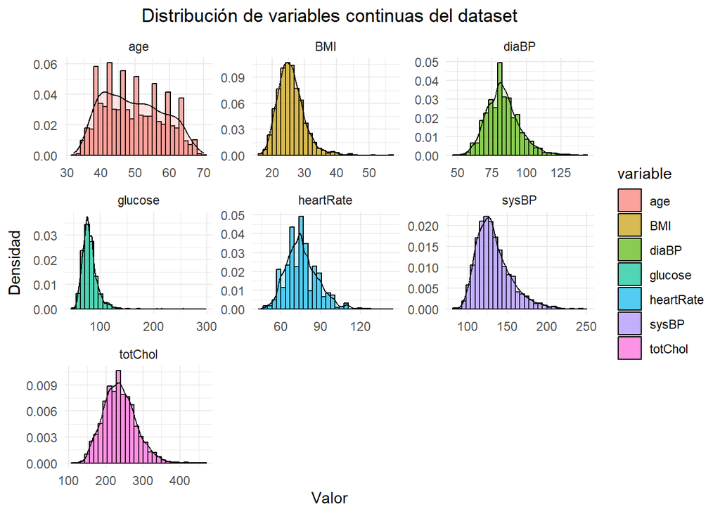

```r
#Variables continuas a analizar:
vars_cont <- c("age", "BMI", "totChol", "glucose", "sysBP", "diaBP", "heartRate")

cardio_long <- data %>% #Convertimos a formato largo para poder representar mejor los datos
  select(all_of(vars_cont)) %>%
  pivot_longer(cols = everything(), names_to = "variable", values_to = "valor")

#Generamos un histograma que muestre la distribución de cada variable analizada
ggplot(cardio_long, aes(x = valor, fill = variable)) +
  geom_histogram(aes(y = ..density..), bins = 30, alpha = 0.6, color = "black") +
  geom_density(alpha = 0.2) +
  facet_wrap(~variable, scales = "free", ncol = 3) + #Separamos individualmente
  theme_minimal() +
  labs(title = "Distribución de variables continuas del dataset",
       x = "Valor", y = "Densidad") +
  theme(plot.title = element_text(hjust = 0.5))
```

**CONCLUSIONES**:

**Edad**: podemos observar que la mayoría de las personas están entre los 40-60 años, dato que se puede confirmar en su respectiva gráfica. Hay, por lo tanto, un predominio de gente adulta de mediana edad.

**BMI**: en la campana de Gauss se aprecia una forma aproximadamente normal centrada en 25-30, lo cual corresponde a un perso normal o sobrepeso leve.

**Presión diastólica (diaBP)**: sigue una distribución bastante simétrica, centrada cerca de 80-85 mmHg. Corresponde a un valor normal. **Glucosa**: distribución altamente asimétrica a la derecha, con sesgo positivo. La mayoría de valores se encuentra entre los 80-100 mg/dL.

**Frecuencia cardíaca (heartRate)**: valores centrados en torno a los 70-80 latidos por minuto, con una ligera cola hacia la derecha. Patrón típico en adultos sanos.

**Presión sistólica (sysBP)**: distribución asimétrica hacia la derecha, con la mayoría entre los 120-150 mmHg. Los valores llegan hasta aproximadamente los 250 mmHg.

**Colesterol total (totChol)**: dsitribución con forma de campana, centrada en torno a los 220 mg/dL, con una cola a la derecha. Indica que muchas personas tienen un colesterol ligeramente alto, ya que el valor normal de colesterol es de <200 mg/dL.

A continuación, realizamos varios gráficos de barras de variables de **carácter categóricas**:

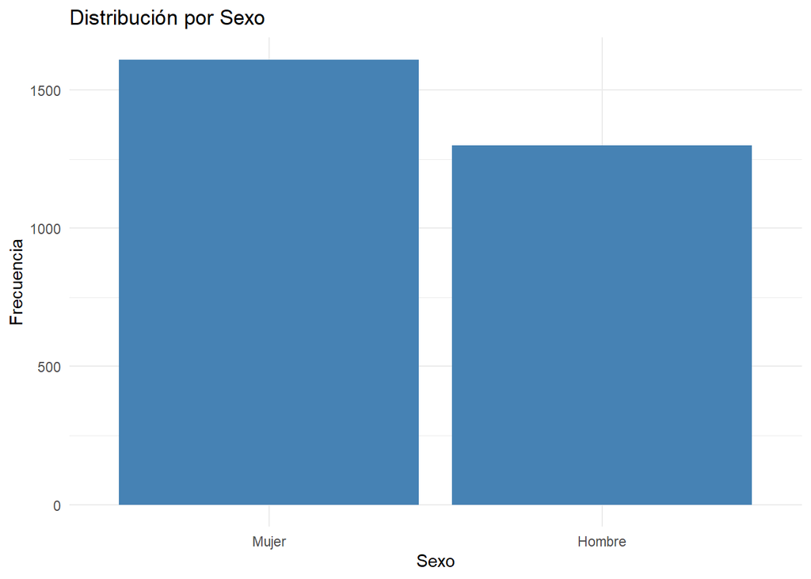

```r
# Crear cada gráfico por separado
sex_barras <- ggplot(data, aes(x = factor(sex))) +
  geom_bar(fill = "steelblue") +
  scale_x_discrete(labels = c("Mujer", "Hombre")) +
  labs(title = "Distribución por Sexo", x = "Sexo", y = "Frecuencia") +
  theme_minimal()

is_smoking_barras <- ggplot(data, aes(x = factor(is_smoking))) +
  geom_bar(fill = "salmon") +
  scale_x_discrete(labels = c("NO", "YES")) +
  labs(title = "Fumadores", x = "Fumador", y = "Frecuencia") +
  theme_minimal()

BPMeds_barras <- ggplot(data, aes(x = factor(BPMeds))) +
  geom_bar(fill = "lightgreen") +
  scale_x_discrete(labels = c("0", "1")) +
  labs(title = "Toma medicación para presión arterial", x = "BPMeds", y = "Frecuencia") +
  theme_minimal()

education_barras <- ggplot(data, aes(x = factor(education))) +
  geom_bar(fill = "orange") +
  scale_x_discrete(labels = c("Primaria", "Secundaria", "Bachillerato", "Universidad")) +
  labs(title = "Nivel educativo", x = "Educación", y = "Frecuencia") +
  theme_minimal()

sex_barras
```

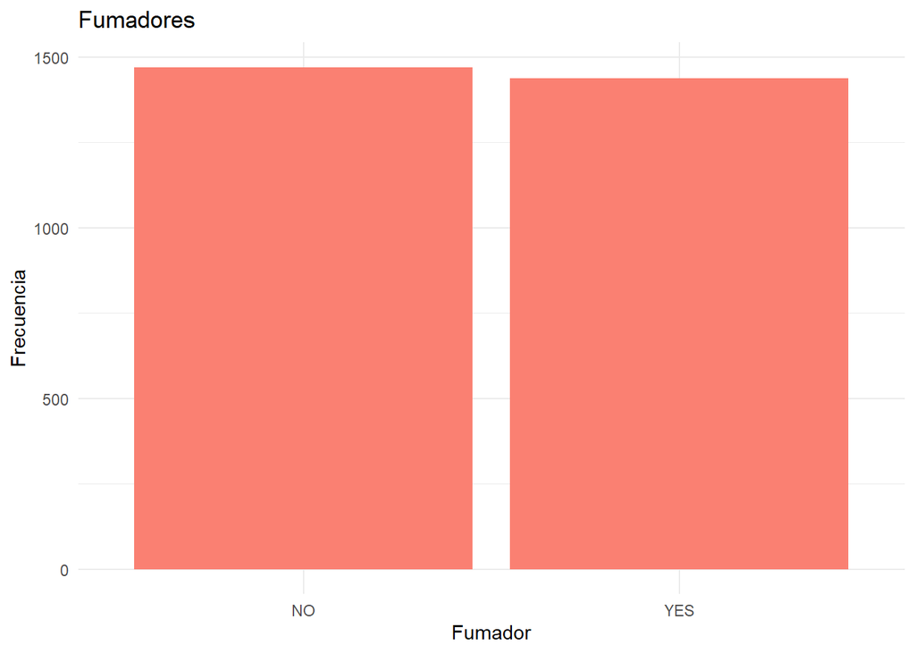

```r
is_smoking_barras
```

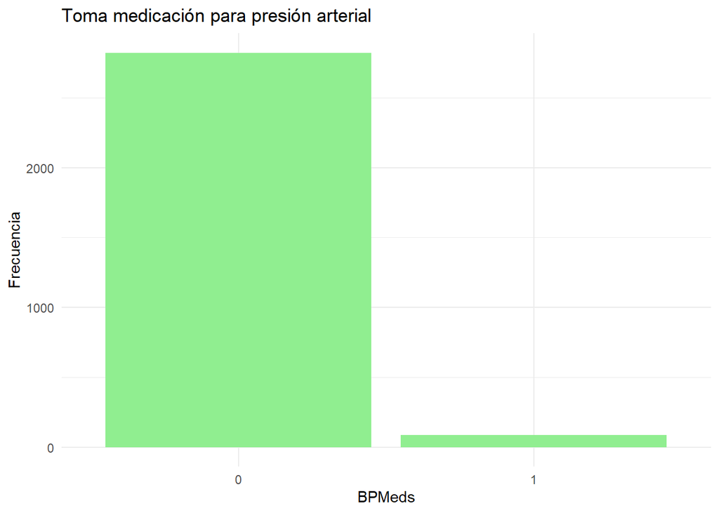

```r
BPMeds_barras
```

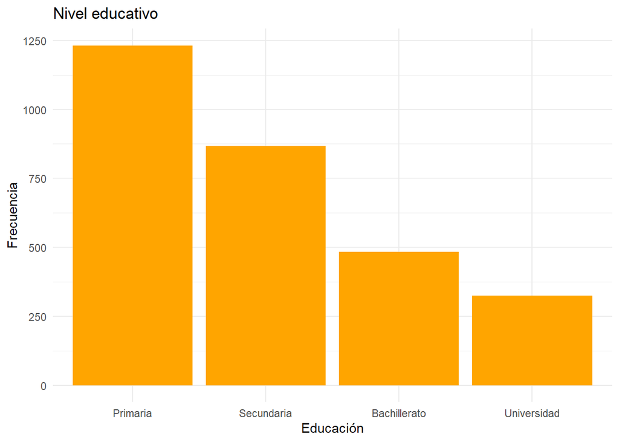

```r
education_barras
```

Representamos ahora la cantidad de cada variable de carácter categórico:

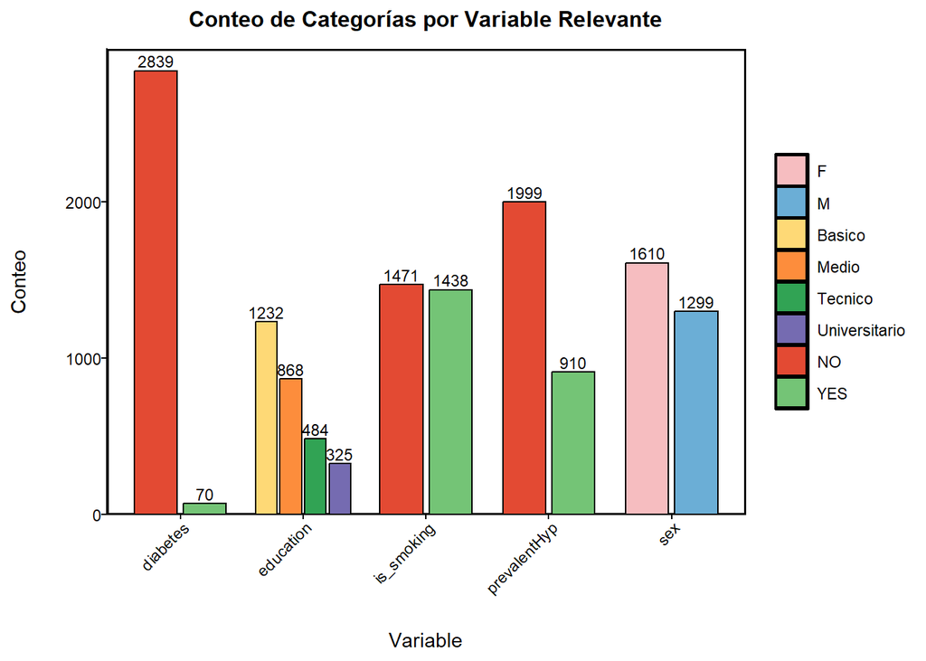

```r
# Seleccionamos solo las variables de interés
vars <- c("sex", "education", "is_smoking", "diabetes", "prevalentHyp")
data_long <- data %>%
  mutate(across(all_of(vars), as.factor)) %>%
  select(all_of(vars)) %>%
  pivot_longer(cols = everything(), names_to = "variable", values_to = "valor") %>%
  group_by(variable, valor) %>%
  summarise(conteo = n(), .groups = "drop") %>%
  mutate(variable_valor = interaction(variable, valor, sep = ": "))

# Definimos los colores personalizados
colores <- c(
  "F" = "#F6BDC0",
  "M" = "#6BAED6",
  "Basico" = "#FED976",
  "Medio" = "#FD8D3C",
  "Tecnico" = "#31A354",
  "Universitario" = "#756BB1",
  "YES" = "#74C476",
  "NO" = "#E34A33",
  "1" = "#9ECAE1",
  "0" = "#FC9272"
)

# Gráfico
grafico_cantidades <- ggplot(data_long, aes(x = variable, y = conteo, fill = valor)) +
  geom_bar(stat = "identity", position = position_dodge(width = 0.8), color = "black", width = 0.7) +
  geom_text(aes(label = conteo),
            position = position_dodge(width = 0.8),
            vjust = -0.3, size = 3) +
  scale_fill_manual(values = colores, na.value = "grey80") +
  scale_y_continuous(expand = expansion(mult = c(0, 0.05))) +
  theme_classic() +
  theme(
    plot.title = element_text(hjust = 0.5, margin = margin(0,0,10,0), size = 12, face = "bold"),
    axis.text.x = element_text(angle = 45, hjust = 1, margin = margin(0,0,10,0)),
    axis.text.y = element_text(margin = margin(0,0,0,10)),
    axis.title.x = element_text(margin = margin(10,0,0,0)),
    axis.title.y = element_text(margin = margin(0,10,0,0)),
    panel.grid.major = element_blank(),
    panel.grid.minor = element_blank(),
    panel.background = element_rect(colour = "black", size = 1),
    legend.title = element_blank()
  ) +
  xlab("Variable") +
  ylab("Conteo") +
  ggtitle("Conteo de Categorías por Variable Relevante")
grafico_cantidades
```

Mostramos también los porcentajes dentro de dichas variables, para poder ver las proporciones de forma más clara:

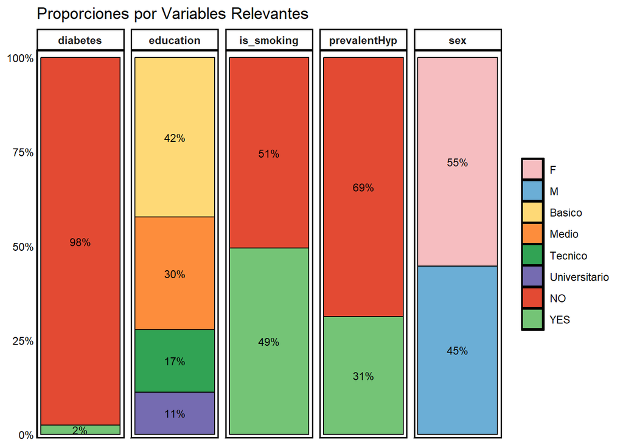

```r
# Seleccionamos las variables de interés
vars <- c("sex", "education", "is_smoking", "diabetes", "prevalentHyp")

# Preparamos los datos con conteos y porcentajes
data_long <- data %>%
  mutate(across(all_of(vars), as.factor)) %>%
  select(all_of(vars)) %>%
  pivot_longer(cols = everything(), names_to = "variable", values_to = "valor") %>%
  group_by(variable, valor) %>%
  summarise(conteo = n(), .groups = "drop") %>%
  group_by(variable) %>%
  mutate(porcentaje = conteo / sum(conteo))  # calculamos el porcentaje por variable

# Colores
colores <- c(
  "F" = "#F6BDC0",
  "M" = "#6BAED6",
  "Basico" = "#FED976",
  "Medio" = "#FD8D3C",
  "Tecnico" = "#31A354",
  "Universitario" = "#756BB1",
  "YES" = "#74C476",
  "NO" = "#E34A33",
  "1" = "#9ECAE1",
  "0" = "#FC9272"
)

# Gráfico de proporciones con etiquetas de porcentaje
grafico_proporciones <- ggplot(data_long, aes(x = 1, y = porcentaje, fill = valor)) +
  geom_bar(stat = "identity", color = "black", width = 0.3) +
  geom_text(aes(label = scales::percent(porcentaje, accuracy = 1)),
            position = position_stack(vjust = 0.5), size = 3) +  # etiqueta en medio del segmento
  scale_fill_manual(values = colores, na.value = "grey80") +
  scale_y_continuous(labels = percent, expand = expansion(mult = c(0.01, 0.02))) +
  facet_wrap(~ variable, nrow = 1, scales = "free_x") +
  theme_classic() +
  theme(
    axis.title = element_blank(),
    axis.text.x = element_blank(),
    axis.ticks = element_blank(),
    strip.background = element_rect(fill = "white", color = "black"),
    strip.text = element_text(face = "bold"),
    panel.grid = element_blank(),
    panel.background = element_rect(colour = "black", size = 1),
    legend.title = element_blank()
  ) +
  ggtitle("Proporciones por Variables Relevantes")

grafico_proporciones
```

A partir de estos gráficos vamos a comprobar los outliers que interpretemos que pueden ser error de medición, sabiendo el rango de valores lógicos de cada variable.

```r
data <- data %>%
  filter(
    totChol >= 100 & totChol <= 500,  # Colesterol total
    sysBP >= 70 & sysBP <= 250,       # Presión sistólica
    glucose >= 50 & glucose <= 300,   # Glucosa
    heartRate >= 40 & heartRate <= 200, # Frecuencia cardíaca
    BMI >= 15 & BMI <= 60               # Índice de masa corporal
  )
```

A continuación, vamos a analizar la relación entre patologías cardiovasculares asociadas a una serie de variables:

1)Analizar los casos cuya presión diastólica supere los 100 mmHg, lo cual es un indicativo de hipertensión:

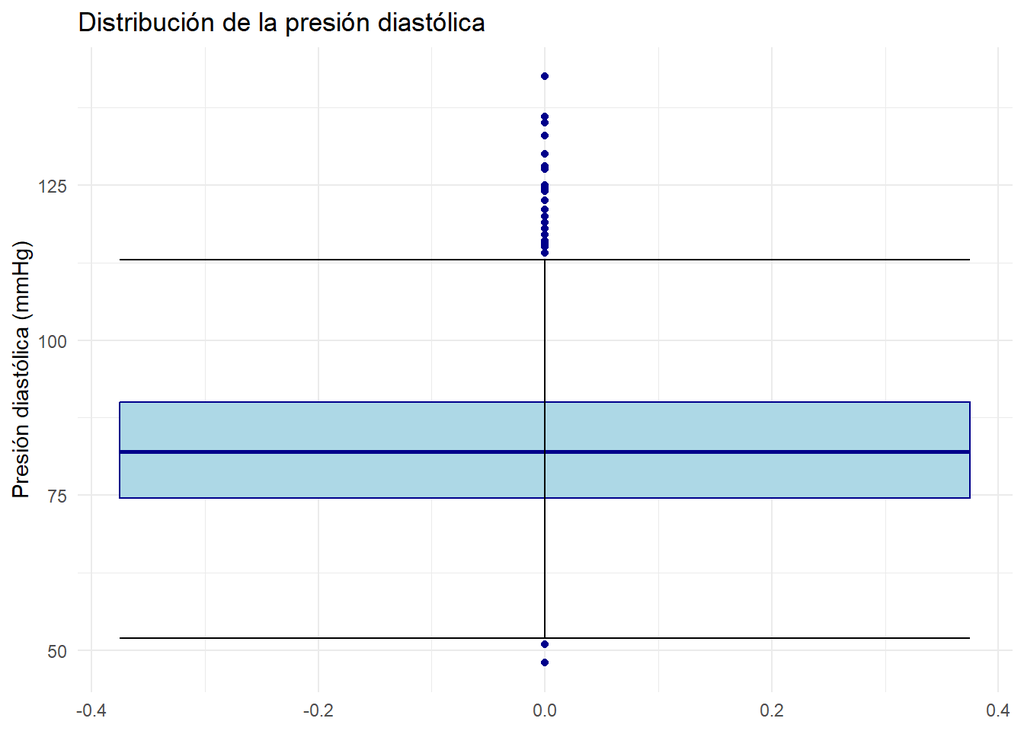

```r
ggplot(data, aes(y = diaBP)) +
  geom_boxplot(fill = "lightblue", color = "darkblue") +
  stat_boxplot(geom=  'errorbar') +
  labs(title = "Distribución de la presión diastólica",
       y = "Presión diastólica (mmHg)") +
  theme_minimal()
```

```r
# Casos con presión diastólica >100
data %>%
  filter(diaBP > 100) %>%
  summarise(casos_hipertension_diastolica = n(),
            porcentaje = n()/nrow(data)*100)
```

```
##   casos_hipertension_diastolica porcentaje
## 1                           226   7.768993
```

La mediana se encuentra cerca de 80-85 mmHg, lo cual indica que la mayoría de pacientes presentan una presión diastólica normal. No obstante, se puede apreciar como hay puntos por encima de los 100 mmHg, que son casos de presión diastólica anormalmente alta.

La tabla muestra que el número total de casos de pacientes con la presión diastólica por encima de los 100 mmHg es de 226, es decir, el 7.77% del total de pacientes.

2)Presión sistólica (sysBP), analizar valores elevados (hipertensión sistólica):

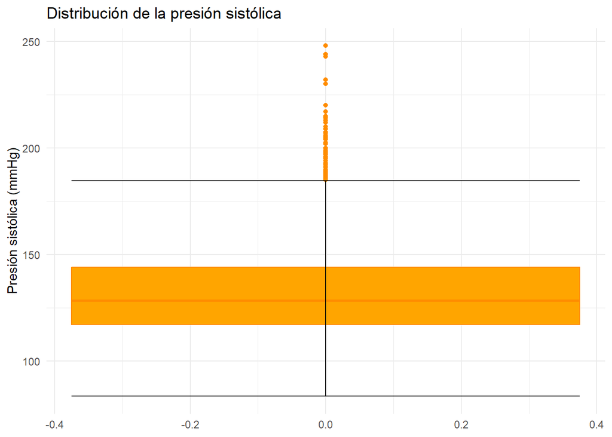

```r
ggplot(data, aes(y = sysBP)) +
  geom_boxplot(fill = "orange", color = "darkorange") +
  stat_boxplot(geom=  'errorbar') +
  labs(title = "Distribución de la presión sistólica",
       y = "Presión sistólica (mmHg)") +
  theme_minimal()
```

```r
# Casos con sysBP >140 mmHg
data %>%
  filter(sysBP > 140) %>%
  summarise(casos_hipertension_sistolica = n(),
            porcentaje = n()/nrow(data)*100)
```

```
##   casos_hipertension_sistolica porcentaje
## 1                          848   29.15091
```

En este caso, la mediana se encuentra cerca de 120-130 mmHg, lo cual indica que la mayoría de pacientes presentan una presión sistólica normal. No obstante, se puede apreciar como hay puntos por encima de los 140-160 mmHg, que son casos de presión sistólica anormalmente alta.

La tabla muestra que el número total de casos de pacientes con la presión sistólica por encima de los 140-160 mmHg es de 848, es decir, el 29.15% del total de pacientes.

3. Glucosa: analizar la cola larga de valores altos >150-200 mg/dL (hiperglucemia/diabetes):

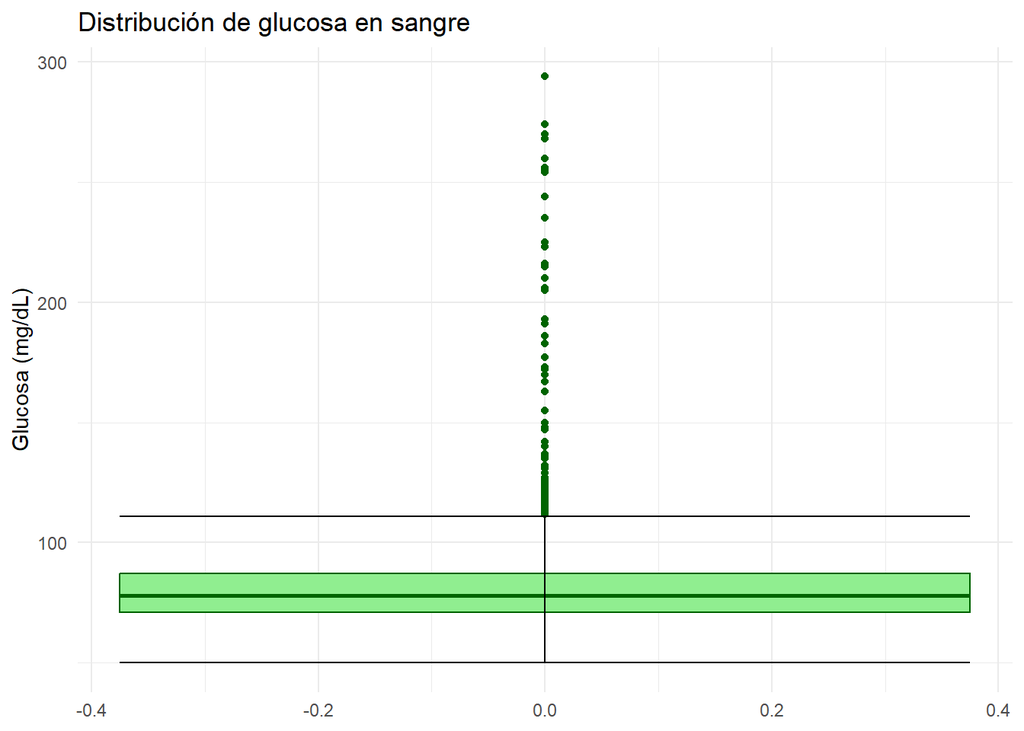

```r
ggplot(data, aes(y = glucose)) +
  geom_boxplot(fill = "lightgreen", color = "darkgreen") +
  stat_boxplot(geom=  'errorbar') +
  labs(title = "Distribución de glucosa en sangre",
       y = "Glucosa (mg/dL)") +
  theme_minimal()
```

```r
# Casos con glucosa >150 mg/dL
data %>%
  filter(glucose > 150) %>%
  summarise(casos_altos_glucosa = n(),
            porcentaje = n()/nrow(data)*100)
```

```
##   casos_altos_glucosa porcentaje
## 1                  32   1.100034
```

La tabla muestra que el número total de casos de pacientes con esta condición es de 32, apenas el 1.1% del total de pacientes.

4. Frecuencia cardíaca (heartRate): analizar valores >100 bpm (taquicardia):

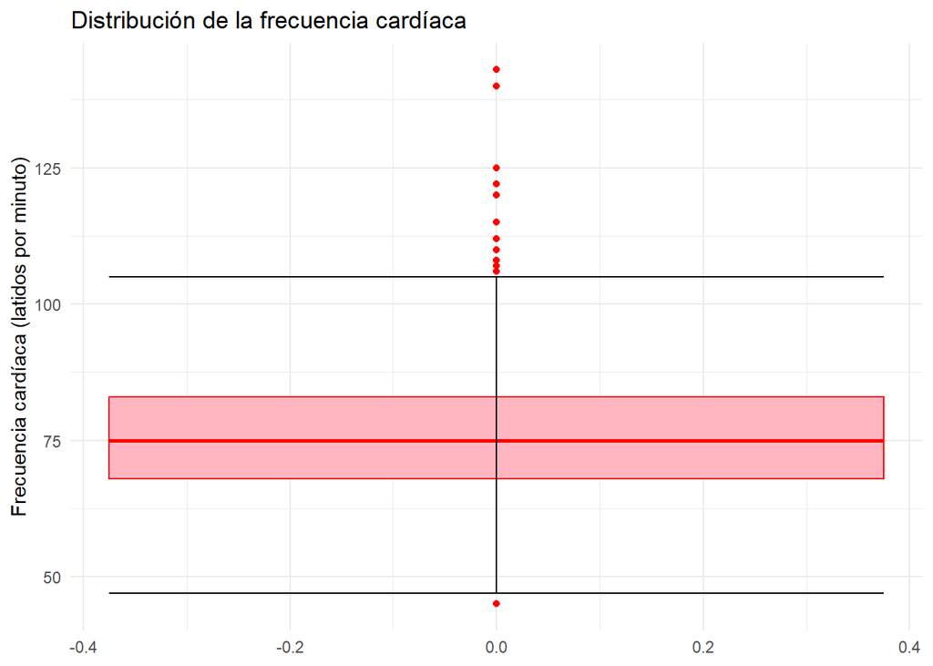

```r
ggplot(data, aes(y = heartRate)) +
  geom_boxplot(fill = "lightpink", color = "red") +
  stat_boxplot(geom=  'errorbar') +
  labs(title = "Distribución de la frecuencia cardíaca",
       y = "Frecuencia cardíaca (latidos por minuto)") +
  theme_minimal()
```

```r
# Casos con heartRate >100 bpm
data %>%
  filter(heartRate > 100) %>%
  summarise(casos_taquicardia = n(),
            porcentaje = n()/nrow(data)*100)
```

```
##   casos_taquicardia porcentaje
## 1                69   2.371949
```

Se comprueba que los latidos por minuto son aproximadamente 75 lat/min. Es apreciable como a pesar de la tendencia general existen casos que presentan rasgos de taquicardia al tener una freciencia cardíaca que supera los 100 lat/min.

La tabla muestra que el número total de casos de pacientes taquicárdicos es de 69, llegando simplemente al 2.37% del total de pacientes.

5. Colesterol total (totChol): analizar casos extremos >300 mg/dL (hipercolesterolemia):

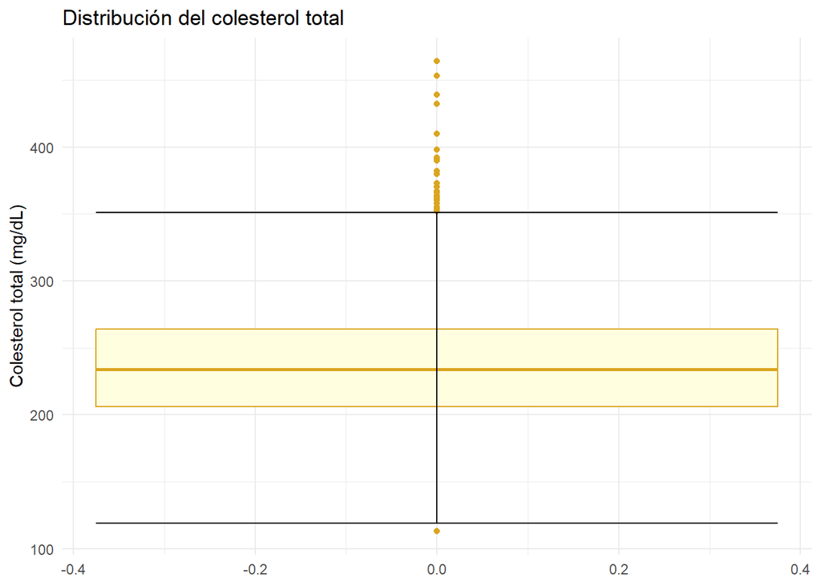

```r
ggplot(data, aes(y = totChol)) +
  geom_boxplot(fill = "lightyellow", color = "goldenrod") +
  stat_boxplot(geom=  'errorbar') +
  labs(title = "Distribución del colesterol total",
       y = "Colesterol total (mg/dL)") +
  theme_minimal()
```

```r
# Casos con totChol >300 mg/dL
data %>%
  filter(totChol > 300) %>%
  summarise(casos_hipercolesterolemia = n(),
            porcentaje = n()/nrow(data)*100)
```

```
##   casos_hipercolesterolemia porcentaje
## 1                       231   7.940873
```

En este último caso evaluado, la mediana de valores de colesterol presente en los pacientes es de unos 240 mg/dL. Sin embargo, en la gráfica se ve cómo existen pacientes que presentan hipercolesterolemia al superar los 300 mg/dL.

La tabla muestra que el número total de casos de pacientes con hipercolesterolemia es de hasta 231, alcanzando un 7.94% del total de pacientes.

##EJERCICIOS DE ANÁLISIS ESTADÍSTICO:

### EJERCICIO 1: ASOCIACIÓN DE FACTORES DE RIESGO CON EL DESARROLLO DE ENFERMEDAD CORONARIA CON TEST DE FISHER

En este ejercicio analizaremos la asociación entre los cuatro posibles factores de riesgo cardiovascular (tabaquismo, accidente cerebrovascular previo, hipertensión y diabetes) y el desarrollo de enfermedad coronaria en 10 años. Generando tablas de contingencia y evaluando la significancia estadística mediante el test de Fisher podremos comprobar si existe o no dicha relación.

#### CÓDIGO DE ANÁLISIS CON CREACIÓN DE TABLAS DE CONTINGENCIA

```r
#Factores de riesgo que queremos analizar
factores <- c("is_smoking", "prevalentStroke", "prevalentHyp", "diabetes")

#Mostramos una tabla de contingencia para cada variable incluida en factores
tablas <- lapply(factores, function(var) {
  cat("\n\n### Tabla de contingencia:", var, "\n")

  tabla <- matrix(0, nrow = 2, ncol = 2)
  rownames(tabla) <- c("Sin factor", "Con factor")
  colnames(tabla) <- c("Sin CHD", "Con CHD")

  idx_chd <- which(data$TenYearCHD == "YES")

  tabla[1, 1] <- sum(data[-idx_chd, var] == "NO")   # Sin factor, Sin CHD
  tabla[2, 1] <- sum(data[-idx_chd, var] == "YES")  # Con factor, Sin CHD
  tabla[1, 2] <- sum(data[idx_chd, var] == "NO")    # Sin factor, Con CHD
  tabla[2, 2] <- sum(data[idx_chd, var] == "YES")   # Con factor, Con CHD

  print(tabla)
  return(tabla)
})
```

```
##
##
## ### Tabla de contingencia: is_smoking
##            Sin CHD Con CHD
## Sin factor    1268     203
## Con factor    1205     233
##
##
## ### Tabla de contingencia: prevalentStroke
##            Sin CHD Con CHD
## Sin factor    2462     429
## Con factor      11       7
##
##
## ### Tabla de contingencia: prevalentHyp
##            Sin CHD Con CHD
## Sin factor    1778     221
## Con factor     695     215
##
##
## ### Tabla de contingencia: diabetes
##            Sin CHD Con CHD
## Sin factor    2426     413
## Con factor      47      23
```

```r
names(tablas) <- factores #Para poder acceder a ellas con más comodidad
```

De estas las tablas de contingencia podemos sacar las siguientes conclusiones:

1. is_smoking:
- Sin fumar: 203/1471 = 13.8% tienen CHD.
- Con fumar: 233/1438 = 16.2% tienen CHD.

Presenta una asociación moderada con CDH, ya que apenas hay diferencias entre si fumar o no fumar afecta l riesgo de padecer alguna enfermedad cardiovascular en 10 años.

2. prevalentStroke:
- sin stroke: 429/2891 = 14.8% tienen CHD.
- con stroke: 7/18 = 38.9% tienen CHD.

Esto indica que el hecho de haber sufrido un accidente cerebrovascular previo hace que las probabilidades de tener un CHD sean mucho mayores a la de las personas sin antecedentes de stroke. Esta variable es por lo tanto un factor de riesgo coronario importante.

3. prevalentHyp:
- Sin hipertensión: 221/1999 = 11.1% tienen CHD.
- Con hipertensión: 215/910 = 23.6% tienen CHD.

En este caso existe también una fuerte asociación entre tener hipertensión y sufrir algun tipo de riesgo cardiovascular.

4. diabetes:
- Sin diabetes: 413/2839 = 14.5% tienen CHD.
- Con diabetes: 23/70 = 32.9% tienen CHD.

También podemos apreciar que el hecho de sufrir diabetes es un factor de riesgo al presentar una mayor proporción de casos con CHD.

Sin embargo, a pesar de estas conclusiones que se obtienen a raíz de las tablas de contingencia, no sabemos aún con certeza si estos datos presentan significancia estadística. Pueden no ser fiables y llevarnos a estimaciones erróneas.

Es importante fundamentar y razonar estadísticamente si los datos obtenidos son consistentes. Por ello, vamos a realizar un **test de Fisher** independiente para cada tabla obtenida. De esta forma podremos determinar si realmente existe alguna asociación entre cada factor de riesgo (tabaquismo, antecedentes de stroke, hipertensión y diabetes) frente a la posibilidad de desarrollar una enfermedad coronaria en los próximos 10 años (`TenYearCHD`).

Las hipótesis estadísticas para este test son las siguientes:

-**Hipótesis nula (H₀):** el factor no influye en el riesgo de enfermedad coronaria.

-**Hipótesis alternativa (H₁):** el factor aumenta la probabilidad de padecer enfermedad coronaria (TenYearCHD = ‘YES’).

#### CONTROL DE FALSOS POSITIVOS

Para controlar la tasa de falsos positivos, se va a aplicar un ajuste de los valores *p* mediante el método de *False Discovery Rate (FDR)*, con <5% de falsos positivos.

```r
#Función para calcular el p-value del test de Fisher para cada factor
fisher_test_CHD <- function(data, variable){

  tabla <- table(data[[variable]], data$TenYearCHD) #Creamos la tabla de contingencia

  test <- fisher.test(tabla, alternative = "greater") #Greater para saber si aumenta el riesgo de CHD

  return(test$p.value)
}

pvalues <- sapply(factores, fisher_test_CHD, data = data) #Calculamos el p-values para cada factor

pvalues_ajustados <- p.adjust(pvalues, method = "fdr") #Ajustamos los p-values con el metodo fdr

odds_ratios <- sapply(factores, function(var){ #Calcular Odds Ratio para cada factor
  tabla <- table(data[[var]], data$TenYearCHD)
  fisher.test(tabla)$estimate
})

resultados_fdr <- data.frame(
  P_Value = round(pvalues, 5),
  P_Value_Ajustado = round(pvalues_ajustados, 5),
  Odds_Ratio = round(odds_ratios, 2),
  Significativo = ifelse(pvalues_ajustados < 0.05, "Sí", "No") #<5% de falsos positivos
)

print(resultados_fdr)
```

```
##                 P_Value P_Value_Ajustado Odds_Ratio Significativo
## is_smoking      0.03890          0.03890       1.21            Sí
## prevalentStroke 0.01152          0.01536       3.65            Sí
## prevalentHyp    0.00000          0.00000       2.49            Sí
## diabetes        0.00012          0.00023       2.87            Sí
```

**INTERPRETACIÓN RESULTADOS:**

Con un nivel de significancia α = 0.05: 1. is_smoking (p-valor = 0.0389): se rechaza H₀. Hay evidencia estadística suficiente de asociación entre tabaquismo y CHD.

Odds ratio = 1.21 indica un riesgo de un 21% más de probabilidades de desarrollar CHD en comparación con los no fumadores.

2. prevalentStroke (p-valor = 0.01152): se rechaza H₀. Existe asociación significativa entre haber sufrido un stroke y desarrollar CHD.

Odds ratio = 3.65 indica que quienes tuvieron un stroke tienen 3.65 veces más probabilidad de desarrollar CHD.

3. prevalentHyp (p-valor < 0.001): se rechaza H₀. Existe asociación muy significativa entre hipertensión y CHD.

Odds ratio = 2.49 indica que las personas hipertensas tienen 2.49 veces más probabilidad de desarrollar CHD.

4. diabetes (p-valor = 0.00012): se rechaza H₀. Existe asociación significativa entre diabetes y CHD.

Odds ratio = 2.87 indica que las personas diabéticas tienen 2.87 veces más probabilidad de desarrollar CHD.

**CONCLUSIONES**: los cuatro factores analizados (is_smoking, prevalentStroke, prevalentHyp y diabetes) presentan una asociación estadísticamente significativa para desarrollar enfermedad coronaria en la próxima década.

Tras hacer el ajuste FDR para controlar la tasa de falsos positivos al 5%, todos los factores han mantenido su significancia estadística.

#### ANÁLISIS EXTENDIDO: VISUALIZACIÓN DE ASOCIACIONES (TEST DE FISHER)

Para complementar el contraste de hipótesis, se genera una representación visual que muestra la fuerza de asociación (*odds ratio*) y la significación estadística (*p-values*) de cada factor analizado.  
De esta forma, se facilita la identificación de los factores de riesgo más influyentes.

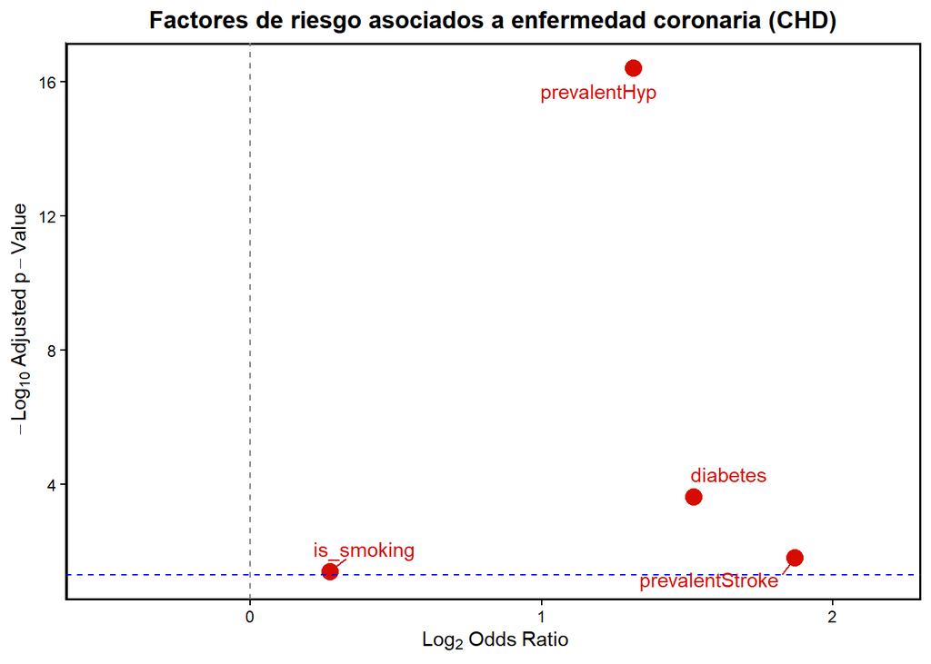

```r
#Preparar datos para el volcano plot
volcano_data <- data.frame(
  Factor = factores,
  Odds_Ratio = odds_ratios,
  P_Value_Ajustado = pvalues_ajustados,
  log2_OR = log2(odds_ratios),
  neglog10_padj = -log10(pvalues_ajustados),
  stringsAsFactors = FALSE
)

#Clasificar significancia
volcano_data$sig <- factor("0", levels = c("0", "1"))
volcano_data$sig[volcano_data$P_Value_Ajustado < 0.05 & volcano_data$log2_OR > 0] <- "1"

#Etiquetas para factores significativos
volcano_data$lab <- ""
volcano_data$lab[volcano_data$sig == "1"] <- volcano_data$Factor[volcano_data$sig == "1"]

#Crear volcano plot
x_pad <- max(abs(volcano_data$log2_OR), na.rm = TRUE) + 0.3

ggplot(volcano_data, aes(x = log2_OR, y = neglog10_padj, colour = sig)) +
  geom_point(size = 4) +
  theme_classic() +
  scale_x_continuous(limits = c(-0.5, x_pad)) +
  scale_color_manual(
    values = c("0" = "#000000", "1" = "#D60C00FF"),
    drop = FALSE
  ) +
  theme(
    panel.grid.major = element_blank(),
    panel.grid.minor = element_blank(),
    panel.background = element_rect(colour = "black", size = 1),
    legend.position = "none",
    plot.title = element_text(hjust = 0.5, face = "bold")
  ) +
  xlab(bquote(~Log[2]~Odds~Ratio)) +
  ylab(bquote(~-Log[10]~Adjusted~p-Value)) +
  geom_hline(yintercept = -log10(0.05), linetype = "dashed", color = "blue") +
  geom_vline(xintercept = 0, linetype = "dashed", color = "gray50") +
  geom_text_repel(
    aes(label = lab),
    box.padding = 0.5,
    point.padding = 0.3,
    max.overlaps = 10
  ) +
  ggtitle("Factores de riesgo asociados a enfermedad coronaria (CHD)")
```

Los 4 factores están por encima de la línea de significancia y hacia la derecha, indicando que todos aumentan significativamente el riesgo de CHD. prevalentStroke tiene el efecto más fuerte (más a la derecha), mientras que prevalentHyp es el más significativo estadísticamente (más arriba). Por el contrario, is_smoking es el que tiene menor peso estadístico y el que causa el menor efecto de padecer enfermedades coronarias frente al resto de factores.

### EJERCICIO 2: ANÁLISIS DEL COLESTEROL SEGÚN EDAD Y RIESGO DE CHD CON SAPHIRO Y KRUSKAL-WALLIS

En este ejercicio se analiza si los niveles de colesterol total (`totChol`) difieren significativamente en función de dos factores:

1. El **grupo de edad** del individuo (jóvenes, adultos o mayores).
2. La **presencia de riesgo coronario a 10 años (TenYearCHD)**.

El objetivo es comprobar si el colesterol varía entre grupos de edad, y si además las personas con CHD presentan niveles más altos, así como si el efecto de la edad es diferente en función del riesgo coronario.

Comenzamos clasificando la información en una tabla que permite observar cuántos individuos pertenecen a cada grupo de edad y cuántos de ellos presentan riesgo coronario.

```r
data_ej2 <- data

data_ej2$grupo_edad <- NA
data_ej2$grupo_edad[data_ej2$age < 40] <- "Jóvenes"
data_ej2$grupo_edad[data_ej2$age >= 40 & data_ej2$age < 60] <- "Adultos"
data_ej2$grupo_edad[data_ej2$age >= 60] <- "Mayores"

data_ej2$grupo_edad <- factor(data_ej2$grupo_edad,
                          levels = c("Jóvenes", "Adultos", "Mayores"))

# --- Comprobar distribución ---
table(data_ej2$grupo_edad, data_ej2$TenYearCHD)
```

```
##
##             NO  YES
##   Jóvenes  380   17
##   Adultos 1755  282
##   Mayores  338  137
```

Nos interesa saber también la media, desviación estándar y número de casos de colesterol para cada combinación de edad y riesgo coronario.

```r
aggregate(totChol ~ grupo_edad + TenYearCHD, data = data_ej2,
          FUN = function(x) c(Media = mean(x, na.rm = TRUE),
                              Desv = sd(x, na.rm = TRUE),
                              N = length(x)))
```

```
##   grupo_edad TenYearCHD totChol.Media totChol.Desv  totChol.N
## 1    Jóvenes         NO     213.26316     39.58357  380.00000
## 2    Adultos         NO     236.74017     42.51562 1755.00000
## 3    Mayores         NO     251.25740     41.89880  338.00000
## 4    Jóvenes        YES     233.00000     49.01275   17.00000
## 5    Adultos        YES     247.76241     47.86135  282.00000
## 6    Mayores        YES     247.87591     42.21173  137.00000
```

Reresentamos los datos para una mejor valoración de su comportamiento:

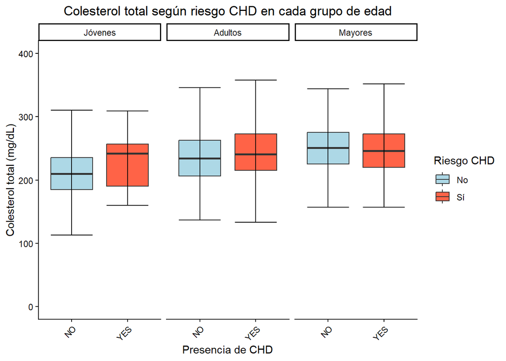

```r
ggplot(data_ej2, aes(x = TenYearCHD, y = totChol, fill = TenYearCHD)) +
  geom_boxplot(outlier.shape = NA) +  #Ocultamos outliers
  stat_boxplot(geom = 'errorbar') +
  facet_wrap(~ grupo_edad) +
  labs(title = "Colesterol total según riesgo CHD en cada grupo de edad",
       x = "Presencia de CHD",
       y = "Colesterol total (mg/dL)") +
  scale_fill_manual(values = c("lightblue", "tomato"),
                    labels = c("No", "Sí"),
                    name = "Riesgo CHD") +
  coord_cartesian(ylim = c(0, 400)) +  # Ajustamos el eje y
  theme_classic() +
  theme(
    axis.text.x = element_text(angle = 45, hjust = 1),
    plot.title = element_text(hjust = 0.5)
  )
```

El gráfico muestra cómo los niveles de colesterol total aumentan algo con la edad, siendo ligeramente más elevados en los grupos de adultos y mayores respecto a los jóvenes. Además, dentro de los grupos de jóvenes y adultos, se aprecia cómo las personas con riesgo de enfermedad coronaria presentan valores de colesterol ligeramente superiores a las que no tienen riesgo.

Estas comparaciones y conclusiones iniciales se pueden sustentar com mayor robustez mediante los análisis estadísticos.

En primer lugar, aplicamos el test de Shapiro-Wilk para comprobar si las variables con y sin enfermedad coronaria sigue una distribución normal. De esta forma sabremos si el test adecuado es ANOVA o Kruskal_Wallis.

Las hipótesis son las siguientes:

- **Hipótesis nula (H₀):** los datos provienen de una distribución normal.
- **Hipótesis alternativa (H₁):** los datos no provienen de una distribución normal.

```r
#Normalidad del colesterol según CHD
shapiro.test(data_ej2$totChol[data_ej2$TenYearCHD == "NO"])
```

```
##
##  Shapiro-Wilk normality test
##
## data:  data_ej2$totChol[data_ej2$TenYearCHD == "NO"]
## W = 0.98674, p-value = 2.059e-14
```

```r
shapiro.test(data_ej2$totChol[data_ej2$TenYearCHD == "YES"])
```

```
##
##  Shapiro-Wilk normality test
##
## data:  data_ej2$totChol[data_ej2$TenYearCHD == "YES"]
## W = 0.97559, p-value = 1.091e-06
```

En ambos grupos los valores de p son < 0.05, por lo que se rechaza la hipótesis nula de normalidad. Es decir, que la distribución de colesterol total (totChol) no sigue una distribución normal en ninguno de los dos grupos.

El test correcto a utilizar a continuación es el test no paramétrico de Kruskal–Wallis:

```r
#Kruskal-Wallis para Jóvenes
kruskal.test(totChol ~ TenYearCHD, data = filter(data_ej2, grupo_edad == "Jóvenes"))
```

```
##
##  Kruskal-Wallis rank sum test
##
## data:  totChol by TenYearCHD
## Kruskal-Wallis chi-squared = 3.01, df = 1, p-value = 0.08275
```

```r
#Kruskal-Wallis para Adultos
kruskal.test(totChol ~ TenYearCHD, data = filter(data_ej2, grupo_edad == "Adultos"))
```

```
##
##  Kruskal-Wallis rank sum test
##
## data:  totChol by TenYearCHD
## Kruskal-Wallis chi-squared = 13.079, df = 1, p-value = 0.0002986
```

```r
#Kruskal-Wallis para Mayores
kruskal.test(totChol ~ TenYearCHD, data = filter(data_ej2, grupo_edad == "Mayores"))
```

```
##
##  Kruskal-Wallis rank sum test
##
## data:  totChol by TenYearCHD
## Kruskal-Wallis chi-squared = 0.60603, df = 1, p-value = 0.4363
```

**CONCLUSIONES**:

En conjunto, los resultados indican que la relación entre el colesterol y el riesgo de enfermedad coronaria se vuelve más evidente en la edad adulta, mientras que en edades tempranas o avanzadas no se observan diferencias tan marcadas.

### EJERCICIO 3: ANÁLISIS DE CORRELACIONES, PCA Y MACHINE LEARNING

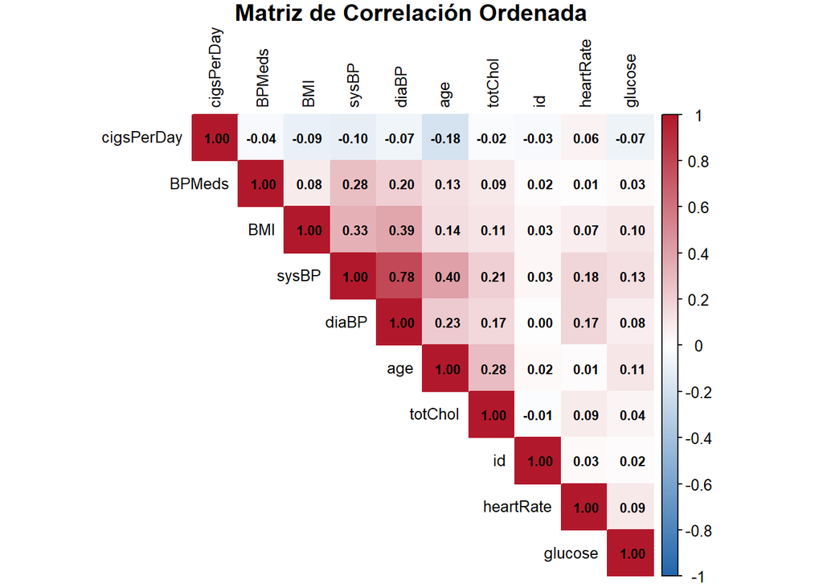

```r
# Calcular correlaciones
corr_matrix <- cor(data %>% dplyr::select_if(is.numeric), use = "complete.obs")

# Visualizar
# Correlación ordenada + heatmap más claro
corrplot(
  corr_matrix,
  method = "color",
  type = "upper",
  order = "hclust",  # Ordena variables por grupos de correlación
  tl.col = "black",
  tl.cex = 0.8,      # Tamaño de texto más pequeño
  addCoef.col = "black",
  number.cex = 0.7,
  col = colorRampPalette(c("#2166AC", "white", "#B2182B"))(200),
  title = "Matriz de Correlación Ordenada",
  mar = c(0,0,1,0)
)
```

El análisis de correlación muestra que la relación lineal más fuerte se observa entre la presión sistólica (sysBP) y la presión diastólica (diaBP), lo cual era esperable dado que ambas variables miden aspectos complementarios de la presión arterial. Se dentifican correlaciones moderadas entre la edad, el índice de masa corporal (BMI) y los valores de presión arterial, indicando que a mayor edad y mayor BMI tienden a presentarse niveles más altos de presión arterial.

El resto de las variables, incluyendo colesterol total, frecuencia cardíaca, glucosa y consumo de cigarrillos, muestran correlaciones bajas o cercanas a cero con la mayoría de las demás variables, lo que sugiere que en este conjunto de datos no existe una relación lineal marcada entre ellas.

En conjunto, los resultados indican que las asociaciones más relevantes se dan en torno a factores relacionados con presión arterial, edad y composición corporal, mientras que otros factores de riesgo cardiovascular parecen no estar linealmente relacionados entre sí. Esto evidencia que algunas relaciones pueden ser independientes o no lineales, por lo que análisis complementarios podrían ser necesarios para capturar interacciones más complejas.

*PCA:*

```r
# Seleccionamos solo variables numéricas para aplicar PCA
data_num <- data %>% dplyr::select_if(is.numeric)

# Escalamos los datos
data_scaled <- scale(data_num)

# Aplicamos PCA
PCs <- prcomp(data_scaled, center = TRUE, scale. = TRUE)

# Verificamos dimensiones
dim(PCs$rotation)
```

```
## [1] 10 10
```

```r
# Varianza explicada por cada componente
summary(PCs)
```

```
## Importance of components:
##                           PC1    PC2    PC3    PC4     PC5     PC6     PC7
## Standard deviation     1.5891 1.0662 1.0239 1.0090 0.98951 0.95528 0.91245
## Proportion of Variance 0.2525 0.1137 0.1048 0.1018 0.09791 0.09126 0.08326
## Cumulative Proportion  0.2525 0.3662 0.4710 0.5728 0.67074 0.76199 0.84525
##                           PC8     PC9    PC10
## Standard deviation     0.8637 0.78279 0.43447
## Proportion of Variance 0.0746 0.06128 0.01888
## Cumulative Proportion  0.9198 0.98112 1.00000
```

Las conclusiones que podemos sacar de estos resultados son las siguientes:

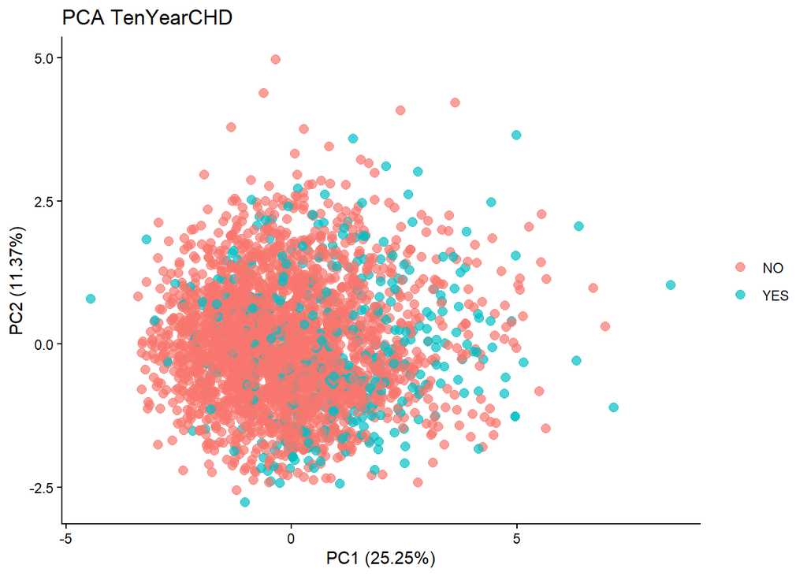

```r
# Añadir PC1 y PC2 + la variable de riesgo
data_pca <- data.frame(PC1 = PCs$x[,1],
                       PC2 = PCs$x[,2],
                       TenYearCHD = as.factor(data$TenYearCHD))

# Gráfico PCA
ggplot(data_pca, aes(x = PC1, y = PC2, color = TenYearCHD)) +
  geom_point(size = 2.5, alpha = 0.7) +
  theme_classic() +
  labs(title = "PCA TenYearCHD",
       x = paste0("PC1 (", round(100 * summary(PCs)$importance[2,1],2), "%)"),
       y = paste0("PC2 (", round(100 * summary(PCs)$importance[2,2],2), "%)")) +
  theme(legend.title = element_blank())
```

Tras aplicar PCA a las variables, podemos observar que los individuos con diagnostico positivo de TenYearCHD no se agrupan en una region diferenciada respecto a los individuos sanos. Esto indica que aunque existen patrones en los datos, la variabilidad atribuible al riesgo cardiovascular no se puede explicar mediante combinaciones lineales simples de las variables originales.

Es necesario aplicar machine learning para evaluar si con modelos no lineales o multivariantes se puede mejorar la capacidad predictiva.

*MACHINE LEARNING*

```r
set.seed(123)

# 1. Convertimos variable objetivo a factor
data$TenYearCHD <- factor(data$TenYearCHD)

# 2. Nos quedamos solo con variables numéricas (excepto la variable objetivo)
numeric_vars <- sapply(data, is.numeric)
numeric_vars["TenYearCHD"] <- FALSE   # excluir la variable objetivo si es numérica 0/1
data_num <- data[, numeric_vars]

# 3. Volvemos a incorporar la variable objetivo
data_num$TenYearCHD <- data$TenYearCHD

# 4. Split estratificado
trainIndex <- createDataPartition(data_num$TenYearCHD, p = 0.7, list = FALSE)
train <- data_num[trainIndex, ]
test  <- data_num[-trainIndex, ]

# 5. Separar X e y
X_train <- train[, -ncol(train)]
X_test  <- test[, -ncol(test)]
y_train <- train$TenYearCHD
y_test  <- test$TenYearCHD

# 6. Escalado solo a las variables numéricas
means <- apply(X_train, 2, mean)
sds   <- apply(X_train, 2, sd)
Xtr_m <- scale(X_train, center = means, scale = sds)
Xte_m <- scale(X_test,  center = means, scale = sds)

# 7. Target en formato 0/1
ytr_bin <- as.numeric(y_train) - 1
yte_bin <- as.numeric(y_test) - 1

# 8. Modelo LASSO
cv_lasso <- cv.glmnet(Xtr_m, ytr_bin, family = "binomial", alpha = 1, type.measure = "auc")
best_lambda <- cv_lasso$lambda.min
cat("Mejor lambda:", best_lambda, "\n")
```

```
## Mejor lambda: 0.004145598
```

```r
# 9. Predicción
prob_lasso <- predict(cv_lasso, s = best_lambda, newx = Xte_m, type = "response")
pred_lasso <- ifelse(prob_lasso > 0.3, "1", "0")
pred_lasso <- factor(pred_lasso, levels = c("0","1"))

# 10. Evaluación
print(table(Real = y_test, Predicho = pred_lasso))
```

```
##      Predicho
## Real    0   1
##   NO  685  56
##   YES 101  29
```

```r
roc_lasso <- roc(yte_bin, as.vector(prob_lasso))
cat("AUC:", auc(roc_lasso), "\n")
```

```
## AUC: 0.7129555
```

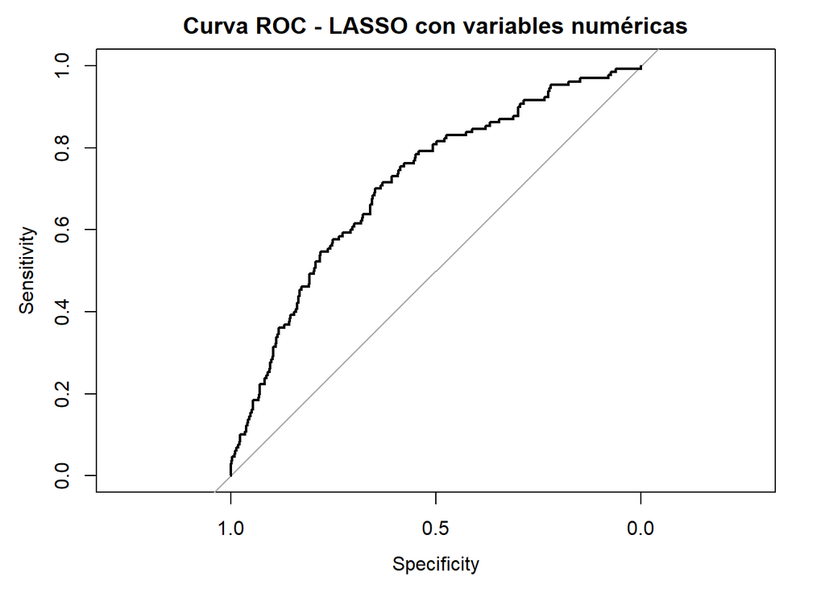

```r
plot(roc_lasso, main = "Curva ROC - LASSO con variables numéricas")
```

**CONCLUSIONES:**

Como lambda es un valor muy pequeño (0.004145598 ), podemos decir que el modelo está intentando equilibrar complejidad y generalización sin eliminar demasiadas variables.

Esto se debe a que nuestro problema está desbalanceado, ya que habla de una enfermedad poco frecuente.

AUC mide la capacidad del modelo para separar correctamente entre NO y YES, y en este caso nuestro modelo tiene AUC ≈ 0.71, lo que indica un rendimiento aceptable

```r
table(test$TenYearCHD)
```

```
##
##  NO YES
## 741 130
```

**CONCLUSIÓN FINAL MACHINE LEARNING:**

El modelo basado en LASSO logra una discriminación moderada (AUC ≈ 0.71), pero presenta baja sensibilidad para detectar pacientes con riesgo de enfermedad coronaria. Esto se debe principalmente al desbalance de clases en los datos.

## RESULTADOS Y COLCUSIONES

El presente análisis ha permitido identificar factores clave asociados al riesgo de enfermedad coronaria en una población de 2.909 individuos, tras un procesamiento previo de los datos originales.

Mediante el test de Fisher se confirmó que los cuatro factores analizados —tabaquismo, antecedentes de accidente cerebrovascular, hipertensión y diabetes— presentan asociación estadísticamente significativa con el desarrollo de enfermedad coronaria a 10 años. Destacan particularmente los antecedentes de stroke (OR = 3.65), diabetes (OR = 2.87) e hipertensión (OR = 2.49), que multiplican considerablemente el riesgo cardiovascular. El tabaquismo, aunque significativo, muestra un efecto más moderado (OR = 1.21).

El análisis realizado en base al grupo de edad evidenció que la relación entre colesterol total y riesgo coronario es más pronunciada en adultos (40-60 años), mientras que en jóvenes y mayores esta asociación no resulta estadísticamente significativa. Este hallazgo sugiere que la edad modula el impacto del colesterol sobre el riesgo cardiovascular.

El análisis de componentes principales reveló que las variables estudiadas no conforman patrones claramente diferenciados entre individuos con y sin riesgo de CHD. Las dos primeras componentes explican únicamente el 36.62% de la variabilidad, lo que indica que el riesgo cardiovascular es multifactorial y no puede ser capturado mediante combinaciones lineales simples de las variables medidas.

En conclusión, este trabajo aporta evidencia cuantitativa sobre la asociación entre factores de riesgo clásicos y enfermedad coronaria, confirmando su relevancia en salud pública y justificando el enfoque preventivo basado en la modificación de hábitos de vida y el control médico de patologías crónicas.